# Assignemnt_4_Clustering

## Interpret the clusters with respect to the numerical variables used in forming the clusters

```r
Phram%>%
  mutate(Cluster = flan$cluster) %>%
  group_by(Cluster)%>% summarise_all("mean")
```

```
## # A tibble: 5 × 10
##   Cluster Market_Cap  Beta PE_Ratio   ROE   ROA Asset_Turnover Leverage
##     <int>      <dbl> <dbl>    <dbl> <dbl> <dbl>          <dbl>    <dbl>
## 1       1      55.8  0.414     20.3  28.7 12.7           0.738    0.371
## 2       2       6.64 0.87      24.6  16.5  4.17          0.6      1.65
## 3       3      31.9  0.405     69.5  13.2  5.6           0.75     0.475
## 4       4     157.   0.48      22.2  44.4 17.7           0.95     0.22
## 5       5      13.1  0.598     17.7  14.6  6.2           0.425    0.635
## # ℹ 2 more variables: Rev_Growth <dbl>, Net_Profit_Margin <dbl>
```

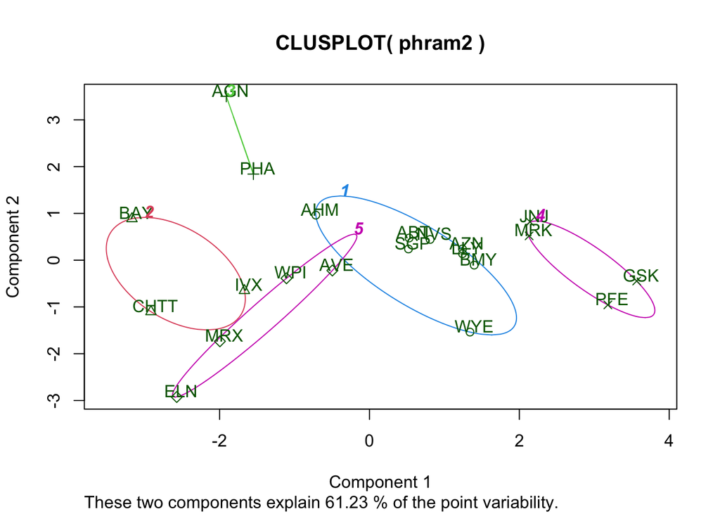

```r
  clusplot(phram2,flan$cluster, color = TRUE, labels = 2,lines = 0)
```

Cluster 2 - BAY, CHTT, IVX - This cluster has high leverage and high beta, but low ROA, net profit margin, and sales growth. These businesses are examples of creative startups in the sector. They are little in terms of market capitalization, and their names are not as well-known as those of well-known brands. Their revenue growth is modest and their net profit margins are low due to their recent establishment, lack of experience, and lack of profitable products that can produce cash flow. They have a low ROA and a high degree of leverage since they heavily rely on R&D. Since they have a high beta and are investing in the future, their price will increase in a rising market.

Cluster 3 - AGN, PHA - There are just two businesses in this cluster: AGN and PHA. Its net profit margin, low ROA, lowest beta, and highest P/E ratio are all present.Consequently, many businesses had modest net profits in the past but great expectations for the future. The market values them highly since they may invest a significant amount of money in D&I in cutting-edge technologies. Nevertheless, investors bear greater risk due to its high price.

Cluster 5 - WPI, MRX,ELN,AVE - This cluster has low market capitalization, low P/E, low turnover rate, high beta, and strong revenue growth. Low ROE, ROA, and turnover rates indicate that these conventional small-sized enterprises may not have very strong capital usage capabilities. However, we can infer that the organizations are being led in the correct direction by either external market developments or internal reformation given the robust rate of revenue growth. The lowest P/E further suggests that their share price is still modest.

## Is there a pattern in the clusters with respect to the numerical variables (10 to 12)? (those not used in forming the clusters)

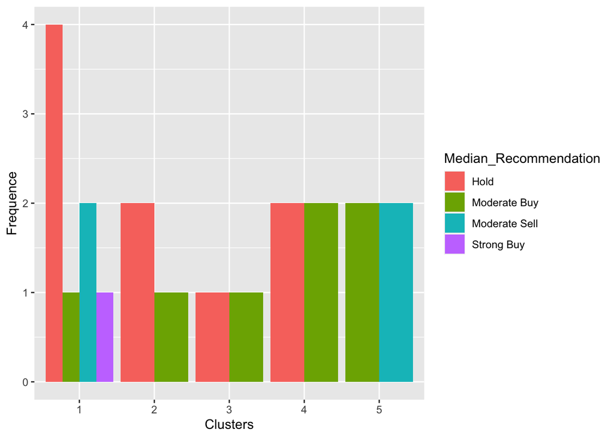

```r
p <- data[12:14] %>% mutate(Clusters=flan$cluster)
ggplot(p, mapping = aes(factor(Clusters), fill =Median_Recommendation))+geom_bar(position='dodge')+labs(x ='Clusters',y ='Frequence')
```

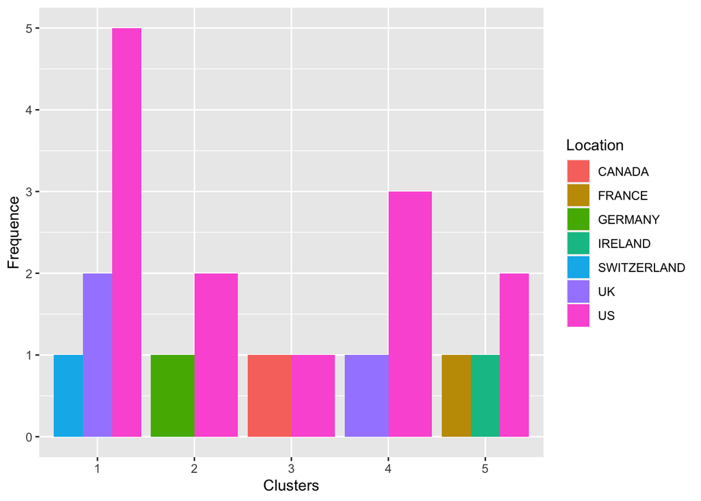

```r
ggplot(p, mapping = aes(factor(Clusters),fill = Location))+
  geom_bar(position = 'dodge')+labs(x ='Clusters',y = 'Frequence')
```

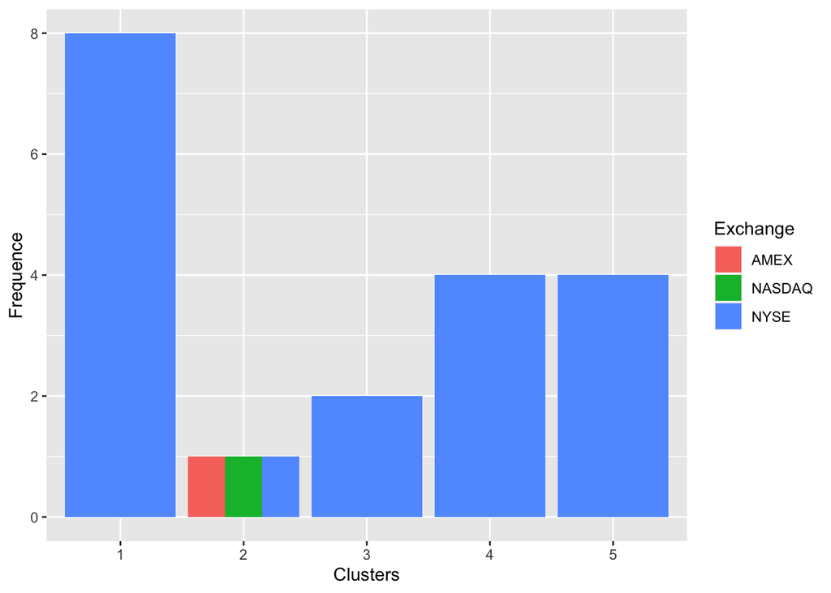

```r
ggplot(p, mapping = aes(factor(Clusters),fill = Exchange))+geom_bar(position = 'dodge')+
  labs(x ='Clusters',y = 'Frequence')
```

## Cluster 1:

Median Recommendation: Cluster 1 is a very strong hold it has 3 locations US,UK and Switzerland and had only one exchange the NYSE

## Cluster 2:

Median Recommendation: Cluster 2 has a strong hold rating and a low buy rating it was in 2 locations us gets more than germany and had (AMEX, NASDAQ, and NYSE)

## Cluster 3:

Median Recommendation: Cluster 3 has a low hold and a low buy, according to the median it was in 2 locations US and canada and had only one exchnage nyse

## Cluster 4:

Median Recommendation: Cluster 4 has a high hold and a high buy, according to the it was in 2 locations US and UK with one stock exchange in NYSE

## Cluster 5:

Median Recommendation: Cluster 5 has a moderate buy and moderate sell and prominent in US and has one stock exchnage in NYSE

## 3.Provide an appropriate name for each cluster using any or all of the variables in the dataset.

cluster 1 - Higher hold cluster cluster 2 - Hold cluster cluster 3 - Lowest cluster cluster 4 - Buy hold cluster cluster 5 - Buy sell cluster